# N-mixture beetles

Viorel Popescu

2024-04-04

# N-mixture (abundance) models for saproxylic beetles

This code analyzes abudance data for the saproxylic beetle *Plagionotus detritus* collected in the Iron Gates Natural Park, Romania and published in Brodie et al. 2019.

Brodie, B. S., V. D. Popescu, R. Iosif, et al. 2019. Non-lethal monitoring of longicorn beetle communities using generic pheromone lures and occupancy models. Ecological Indicators 101:330-340.

# DATA SETUP

Set working directory, read data from a .csv file and examine the data structure; add the two R packages used by this analysis: *unmarked* for N-mixture analyses and *MuMIn* for multi-model inference

```r
library(unmarked)
library(MuMIn)

beetles <- read.csv("data/Pdet_dataset.csv")
names(beetles)
```

```
##  [1] "Trap"        "GroundCover" "AvgDiameter" "DaySurv1"    "DaySurv2"
##  [6] "DaySurv3"    "DaySurv4"    "DaySurv5"    "DaySurv6"    "DaySurv7"
## [11] "DaySurv8"    "DaySurv9"    "DaySurv10"   "DaySurv11"   "DaySurv12"
## [16] "Julian1"     "Julian2"     "Julian3"     "Julian4"     "Julian5"
## [21] "Julian6"     "Julian7"     "Julian8"     "Julian9"     "Julian10"
## [26] "Julian11"    "Julian12"    "Precip1"     "Precip2"     "Precip3"
## [31] "Precip4"     "Precip5"     "Precip6"     "Precip7"     "Precip8"
## [36] "Precip9"     "Precip10"    "Precip11"    "Precip12"    "Pdet1"
## [41] "Pdet2"       "Pdet3"       "Pdet4"       "Pdet5"       "Pdet6"
## [46] "Pdet7"       "Pdet8"       "Pdet9"       "Pdet10"      "Pdet11"
## [51] "Pdet12"
```

```r
attach(beetles)
str(beetles)
```

```
## 'data.frame':    50 obs. of  51 variables:
##  $ Trap       : chr  "E1" "E2" "E3" "E4" ...
##  $ GroundCover: num  0.15 0.5 0.35 0.2 0.25 0.15 0.15 0.85 0.25 0.8 ...
##  $ AvgDiameter: num  51.4 98.8 67.8 79.4 51.1 ...
##  $ DaySurv1   : chr  "18-May" "18-May" "18-May" "18-May" ...
##  $ DaySurv2   : chr  "20-May-15" "20-May-15" "20-May-15" "20-May-15" ...
##  $ DaySurv3   : chr  "22-May-15" "22-May-15" "22-May-15" "22-May-15" ...
##  $ DaySurv4   : chr  "26-May-15" "26-May-15" "26-May-15" "26-May-15" ...
##  $ DaySurv5   : chr  "29-May-15" "29-May-15" "29-May-15" "29-May-15" ...
##  $ DaySurv6   : chr  "1-Jun-15" "1-Jun-15" "1-Jun-15" "1-Jun-15" ...
##  $ DaySurv7   : chr  "3-Jun-15" "3-Jun-15" "3-Jun-15" "3-Jun-15" ...
##  $ DaySurv8   : chr  "7-Jun-15" "7-Jun-15" "7-Jun-15" "7-Jun-15" ...
##  $ DaySurv9   : chr  "8-Jun-15" "8-Jun-15" "8-Jun-15" "8-Jun-15" ...
##  $ DaySurv10  : chr  "10-Jun-15" "10-Jun-15" "10-Jun-15" "10-Jun-15" ...
##  $ DaySurv11  : chr  "12-Jun-15" "12-Jun-15" "12-Jun-15" "12-Jun-15" ...
```

[output cut: 37 more lines]

Setup *unmarked* dataframe using site-specific and survey-specific covariates survey-specific covariates are: JulianDay (day of year) and Precipitation; site-specific covariates are Ground cover and Average tree diameter

Create survey-specific covariates and standardize them

```r
JulianDay = matrix(cbind(Julian1, Julian2, Julian3, Julian4,
                         Julian5, Julian6, Julian7, Julian8,
                         Julian9, Julian10, Julian11, Julian12))
JulianDay = matrix(scale(JulianDay), nrow=50, byrow=F)

Precipitation = matrix(cbind(Precip1, Precip2, Precip3, Precip4,
                             Precip5, Precip6, Precip7, Precip8,
                             Precip9, Precip10, Precip11, Precip12))
Precipitation = matrix(scale(Precipitation), nrow=50, byrow=F)
```

Create an *unmarked* object for our focal species, Plagionotus detritus. Create an R object that can be read by the ‘unmarked’ package. The object contains 3 types of data: 1) detection/nondetection data (the observations grouped into a matrix “y”) 2) site-level covariates; these can be any variables that do not vary with survey occasion, such as landscape characteristics, habitat types, site characteristics etc. - these variables are used to model ABUNDANCE; they can also be used to model DETECTION 3) observation-level covariates; these can be any variables recorded at the time of survey that may influence detection - these variables are used to model DETECTION

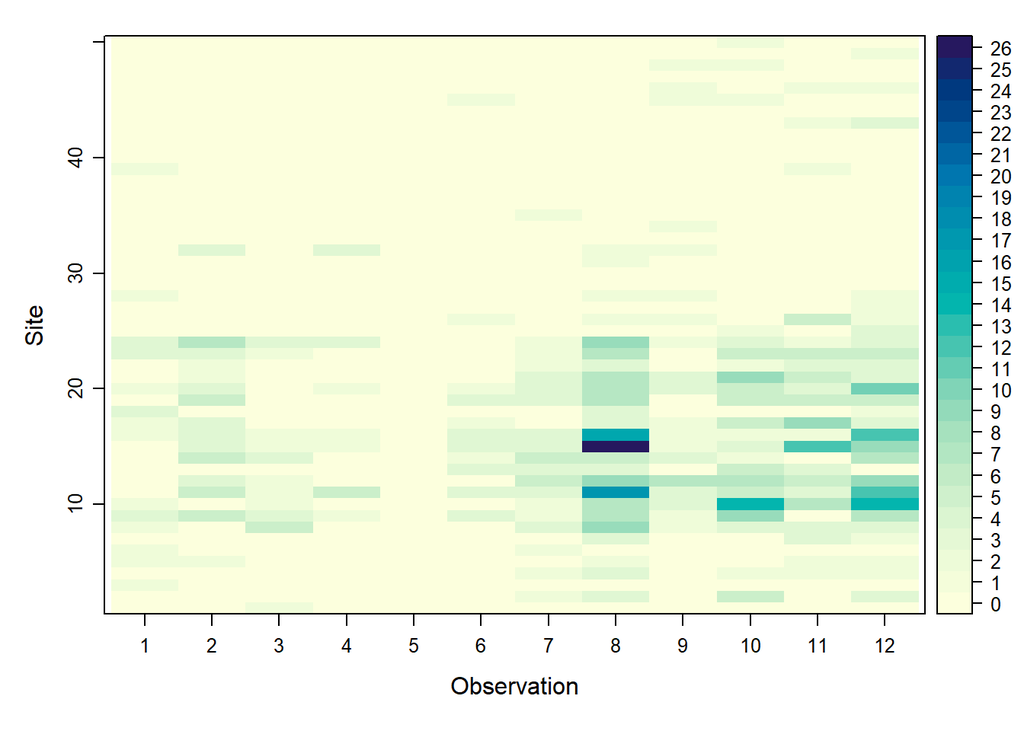

```r
PdetUMF <- with(beetles, {
  unmarkedFramePCount(
    y = cbind(Pdet1, Pdet2, Pdet3, Pdet4, Pdet5, Pdet6, Pdet7,
              Pdet8, Pdet9, Pdet10, Pdet11, Pdet12),
    siteCovs = data.frame(scale(GroundCover), scale(AvgDiameter)),
    obsCovs = list(Julian = JulianDay,
                   Precip = Precipitation))

})

plot(PdetUMF)
```

Count data can follow Poisson or Negative Binomial distributions; if there are a lot of zeroes in the data, count data can also follow a Zero-Inflated Poisson distribution; as such, the first step is to parameterize a model with haphazardly selected variables and test which type of distribution fits the data best.

For simplicity, wil will only use 2 site-level variables in this exercise: Average tree diameter and Ground cover

```r
mP <- pcount(~Julian+Precip ~scale.AvgDiameter. + scale.GroundCover.,
             mixture="P", K=100, data=PdetUMF) # Poisson distribution "P"
mNB <- pcount(~Julian+Precip ~scale.AvgDiameter. + scale.GroundCover.,
              mixture="NB", K=100, data=PdetUMF) # negative binomial "NB"
mZIP <- pcount(~Julian+Precip ~scale.AvgDiameter. + scale.GroundCover.,
              mixture="ZIP", K=100, data=PdetUMF) # zero-inflated Poisson "ZIP"

# model selection using AICc
modelList <- fitList("modP" = mP, "modNB" = mNB, "modZIP" = mZIP)
modSel_Pdet <- modSel(modelList)
modSel_Pdet
```

```
##        nPars     AIC  delta   AICwt cumltvWt
## modNB      7 1383.81   0.00 1.0e+00     1.00
## modZIP     7 1608.36 224.55 1.7e-49     1.00
## modP       6 1690.85 307.05 2.1e-67     1.00
```

The distribution that fits the data best is Negative Binomial and will continue using this distribution for th erest of the analysis.

The analysis has 2 stages: First we need to evaluate the best predictors for detection. Therefore, we run several models that contains the same suite of site-related variables (for modeling abundance), but various combinations of survey-specific variables for modeling detection. The goal is to identify the best variables that explain detection probability, when then use them in the next step of the analysis.

# BUILD AND RUN DETECTION MODELS (using a full model for abundance)

Run several models for detection; the goal is to compare models with different parameterizations for detection using the same vaiables for abundance across models. The function is *pcount* and contains 2 sub-models: the first “~” is the detection submodel; the seond “~” is the abundance submodel.

```r
m0 <- pcount(~1 ~scale.AvgDiameter.+ scale.GroundCover., mixture="NB", K=100, data=PdetUMF)
m1 <- pcount(~Julian ~scale.AvgDiameter.+ scale.GroundCover., mixture="NB", K=100, data=PdetUMF)
m2 <- pcount(~Precip ~scale.AvgDiameter.+ scale.GroundCover., mixture="NB", K=100, data=PdetUMF)
m3 <- pcount(~Julian+Precip ~scale.AvgDiameter.+ scale.GroundCover., mixture="NB", K=100, data=PdetUMF)

# detection model selection using AICc
modelList <- fitList(Null = m0, "mod1" = m1, "mod2" = m2, "mod3" = m3)
modSel_Pdet <- modSel(modelList, nullmod = 'Null')
modSel_Pdet
```

```
##      nPars     AIC  delta   AICwt cumltvWt   Rsq
## mod3     7 1383.81   0.00 1.0e+00     1.00 0.992
## mod1     6 1405.87  22.07 1.6e-05     1.00 0.987
## mod2     6 1619.78 235.97 5.7e-52     1.00 0.094
## Null     5 1622.70 238.90 1.3e-52     1.00 0.000
```

Model 3, which includes both precipitation and Julain day performs best, and we will use these 2 variables in the next step

# BUILD AND RUN MODELS FOR ABUNDANCE

We now run several models that include different variables explaining abundance and the best detection variable(s) identified above. We are only running a small set of models here, but one can build and run many more models based on a priori hypotheses, exppert knowledge about limiting and favorable factors, etc.

```r
Pdet_Null <- pcount(~Julian+Precip  ~1, mixture="NB", K=100, data=PdetUMF)
Pdet_m0 <- pcount(~Julian+Precip  ~scale.GroundCover., mixture="NB", K=100, data=PdetUMF)
Pdet_m1 <- pcount(~Julian+Precip  ~scale.AvgDiameter., mixture="NB", K=100, data=PdetUMF)
Pdet_m2 <- pcount(~Julian+Precip  ~scale.AvgDiameter. + scale.GroundCover.,
                  mixture="NB", K=100, data=PdetUMF)

# model selection using AICc
modelList_Pdet <- fitList(Null = Pdet_Null, m0 = Pdet_m0, m1 = Pdet_m1, m2 = Pdet_m2)
modSel_Pdet <- modSel(modelList_Pdet, nullmod = 'Null')
modSel_Pdet
```

```
##      nPars     AIC delta AICwt cumltvWt    Rsq
## m0       6 1381.88  0.00 0.511     0.51 0.0724
## Null     5 1383.64  1.76 0.212     0.72 0.0000
## m2       7 1383.81  1.93 0.195     0.92 0.0738
## m1       6 1385.53  3.65 0.082     1.00 0.0021
```

The best model only contains Ground Cover as a predictor for beetle abundance. Next, we compute model predictions and estimates of abundance and detection for the species of interest.

```r
# extract coeficients for best model
summary(Pdet_m0)
```

```
##
## Call:
## pcount(formula = ~Julian + Precip ~ scale.GroundCover., data = PdetUMF,
##     K = 100, mixture = "NB")
##
## Abundance (log-scale):
##                    Estimate    SE     z  P(>|z|)
## (Intercept)           2.920 0.230 12.69 6.47e-37
## scale.GroundCover.    0.432 0.221  1.96 5.04e-02
##
## Detection (logit-scale):
##             Estimate     SE      z   P(>|z|)
## (Intercept)   -3.179 0.1118 -28.42 1.03e-177
## Julian         0.797 0.0568  14.03  9.72e-45
## Precip         0.315 0.0621   5.07  3.89e-07
##
## Dispersion (log-scale):
##  Estimate    SE     z  P(>|z|)
##    -0.743 0.216 -3.45 0.000566
##
## AIC: 1381.877
## Number of sites: 50
## optim convergence code: 0
## optim iterations: 71
## Bootstrap iterations: 0
```

```r
coef(Pdet_m0)
```

```
##                lam(Int) lam(scale.GroundCover.)                  p(Int)
##               2.9196445               0.4318698              -3.1789428
##               p(Julian)               p(Precip)            alpha(alpha)
##               0.7969810               0.3151716              -0.7430796
```

```r
# estimate individuals per site from the best model
Pdet_abund <- predict(Pdet_m0, type="state")
Pdet_abund # predicted abundance at each trap location
```

```
##    Predicted        SE     lower    upper
## 1   11.47970  3.919061  5.879468 22.41417
## 2   18.44947  4.245417 11.752043 28.96372
## 3   15.05481  3.861996  9.105782 24.89047
## 4   12.28476  3.889880  6.604497 22.85038
## 5   13.14628  3.863699  7.389824 23.38684
## 6   11.47970  3.919061  5.879468 22.41417
## 7   11.47970  3.919061  5.879468 22.41417
## 8   29.65086  9.696762 15.619520 56.28685
## 9   13.14628  3.863699  7.389824 23.38684
## 10  27.70774  8.405804 15.288637 50.21499
## 11  15.05481  3.861996  9.105782 24.89047
## 12  33.95547 12.884159 16.140887 71.43187
## 13  18.44947  4.245417 11.752043 28.96372
## 14  31.73025 11.185228 15.900710 63.31848
```

[output cut: 36 more lines]

```r
mean(Pdet_abund$Predicted) # mean predicted abundance across all traps
```

```
## [1] 20.29781
```

```r
# compute overall abundance estimates
lcab <- linearComb(Pdet_m0, c(1, 1), type="state")
lcab <- backTransform(lcab)
lcab
```

```
## Backtransformed linear combination(s) of Abundance estimate(s)
##
##  Estimate   SE LinComb (Intercept) scale.GroundCover.
##      28.5 8.95    3.35           1                  1
##
## Transformation: exp
```

```r
# estimate probability of detection from the best model
Pdet_det <- predict(Pdet_m0, type="det")
Pdet_det
```

```
##      Predicted          SE       lower      upper
## 1   0.01021382 0.001679318 0.007396510 0.01408899
## 2   0.03119737 0.005484267 0.022066750 0.04393625
## 3   0.01461927 0.002130051 0.010981577 0.01943829
## 4   0.03300648 0.004099970 0.025849893 0.04205885
## 5   0.02724315 0.003251859 0.021544946 0.03439545
## 6   0.03546716 0.003959259 0.028474014 0.04409984
## 7   0.04222880 0.004558910 0.034143983 0.05212466
## 8   0.05961140 0.006224604 0.048518342 0.07304603
## 9   0.06490756 0.006770886 0.052833552 0.07950921
## 10  0.08402452 0.008869861 0.068194543 0.10312244
## 11  0.09074097 0.009672207 0.073482521 0.11156474
## 12  0.10687268 0.011648702 0.086094450 0.13194161
## 13  0.01021382 0.001679318 0.007396510 0.01408899
## 14  0.03119737 0.005484267 0.022066750 0.04393625
```

[output cut: 586 more lines]

```r
mean(Pdet_det$Predicted)
```

```
## [1] 0.05132901
```

```r
# compute overall detection estimates
lcdet <- linearComb(Pdet_m0, c(1, 1, 1), type="det")
lcdet <- backTransform(lcdet)
lcdet
```

```
## Backtransformed linear combination(s) of Detection estimate(s)
##
##  Estimate     SE LinComb (Intercept) Julian Precip
##     0.112 0.0144   -2.07           1      1      1
##
## Transformation: logistic
```

# PLOT RELATIONSHIPS BETWEEN VARIABLES AND DETECTION PROBABILITY

To plot these relationships, we first create a new data frame for prediction with the variable of interest ranging from min to max values, while keeping all the other variables in the model at their mean value.

```r
# predictions for date
Date_grid <- seq(min(PdetUMF@obsCovs$Julian),
                 max(PdetUMF@obsCovs$Julian),
                 length = 50)
grid <- expand.grid(Julian = Date_grid, Precip = mean(PdetUMF@obsCovs$Precip))
Date_pred <- predict(Pdet_m0, type = "det", as.data.frame(grid))
str(Date_pred)
```

```
## 'data.frame':    50 obs. of  4 variables:
##  $ Predicted: num  0.0119 0.0125 0.0131 0.0138 0.0145 ...
##  $ SE       : num  0.00181 0.00187 0.00193 0.002 0.00206 ...
##  $ lower    : num  0.00883 0.00932 0.00984 0.01038 0.01096 ...
##  $ upper    : num  0.016 0.0168 0.0175 0.0183 0.0191 ...
```

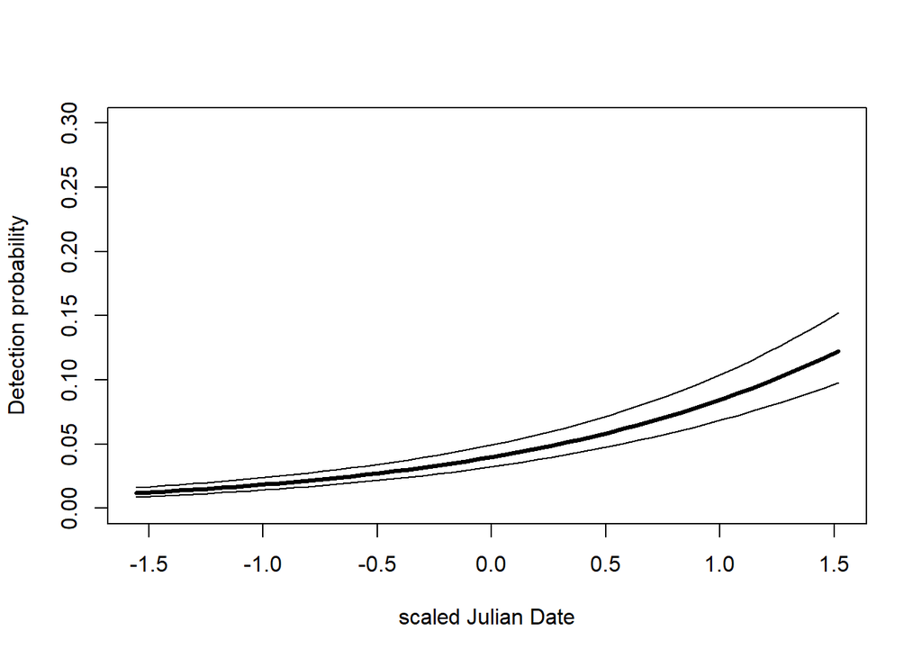

```r
plot(Date_grid,
     Date_pred$Predicted,
     type = "l",
     lwd = 3,
     ylim = c(0,0.3),
     xlab = "scaled Julian Date",
     ylab = "Detection probability")
lines(Date_grid, Date_pred$lower)
lines(Date_grid, Date_pred$upper)
```

```r
# predictions for precipitation
Precip_grid <- seq(min(PdetUMF@obsCovs$Precip),
                max(PdetUMF@obsCovs$Precip),
                length = 50)
grid <- expand.grid(Julian = mean(PdetUMF@obsCovs$Julian), Precip = Precip_grid)
Precip_pred <- predict(Pdet_m0, type = "det", as.data.frame(grid))
str(Precip_pred)
```

```
## 'data.frame':    50 obs. of  4 variables:
##  $ Predicted: num  0.0344 0.0351 0.0358 0.0364 0.0371 ...
##  $ SE       : num  0.00387 0.00391 0.00395 0.00399 0.00404 ...
##  $ lower    : num  0.0276 0.0282 0.0288 0.0294 0.03 ...
##  $ upper    : num  0.0429 0.0436 0.0444 0.0451 0.0459 ...
```

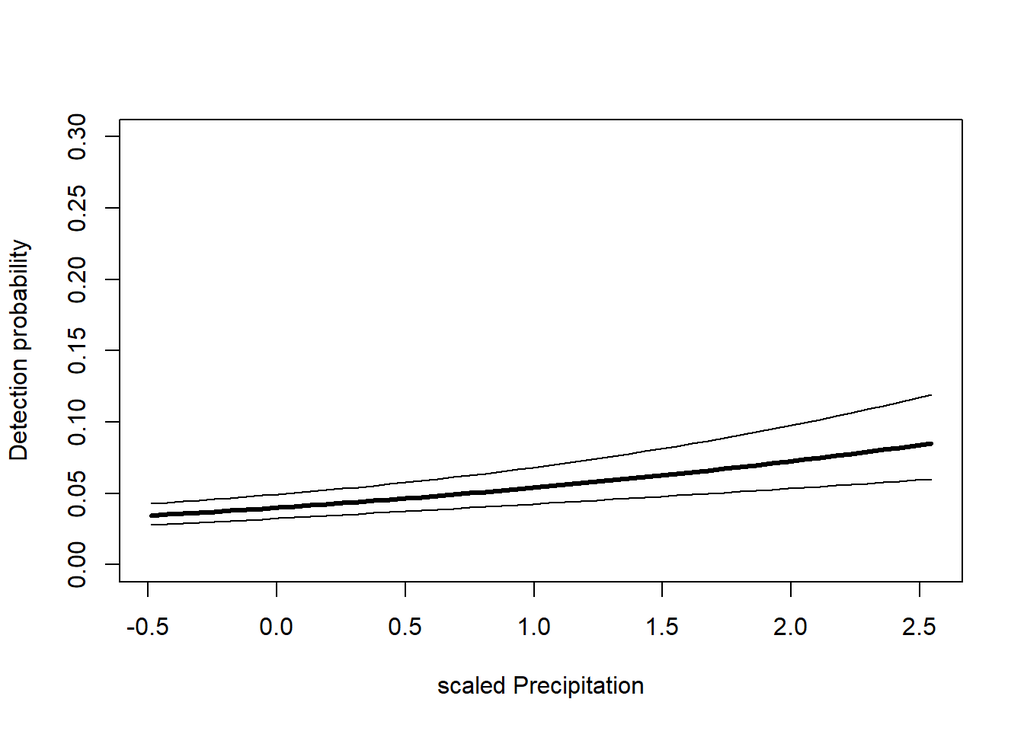

```r
plot(Precip_grid,
     Precip_pred$Predicted,
     type = "l",
     lwd = 3,
     ylim = c(0,0.3),
     xlab = "scaled Precipitation",
     ylab = "Detection probability")
lines(Precip_grid, Precip_pred$lower)
lines(Precip_grid, Precip_pred$upper)
```

# PLOT RELATIONSHIPS BETWEEN VARIABLE Ground Cover AND ABUNDANCE

```r
GC_grid <- seq(min(PdetUMF@siteCovs$scale.GroundCover.),
               max(PdetUMF@siteCovs$scale.GroundCover.),
               length = 50)
scale.GroundCover. <- GC_grid
GC_pred <- predict(Pdet_m0, type = "state", as.data.frame(GC_grid))
str(GC_pred)
```

```
## 'data.frame':    50 obs. of  4 variables:
##  $ Predicted: num  10 10.3 10.5 10.8 11.1 ...
##  $ SE       : num  3.96 3.96 3.95 3.94 3.93 ...
##  $ lower    : num  4.62 4.83 5.05 5.28 5.52 ...
##  $ upper    : num  21.8 21.9 22 22.1 22.2 ...
```

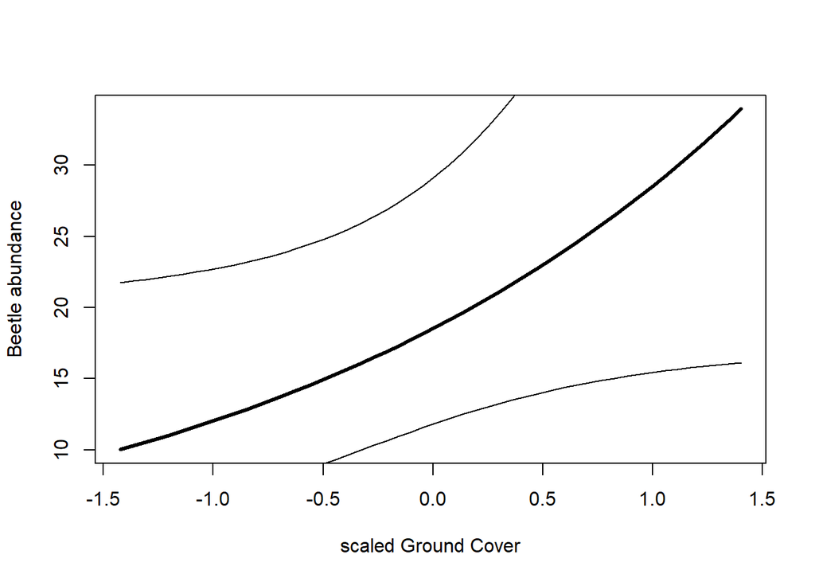

```r
plot(GC_grid,
     GC_pred$Predicted,
     type = "l",
     lwd = 3,
     xlab = "scaled Ground Cover",
     ylab = "Beetle abundance")

lines(GC_grid, GC_pred$lower)
lines(GC_grid, GC_pred$upper)
```